# Marketing Analytics Final

# Data Preprocessing

```r
#install.packages("dplyr")
#install.packages("plyr")
#install.packages("readr")
library("dplyr")
library("plyr")
library("readr")
```

## Data Setup

1. If using all 4 months of data:

```r
# Merge Dataset
# cosmetics.df <- list.files(path = "cosmetics_ecommerce", pattern = "*.csv", full.names = TRUE) %>% lapply(read.csv) %>% bind_rows
# head(cosmetics.df)

# Save the merge dataset to a csv file
# write.csv(cosmetics.df, file = "merged_cosmetics.csv")

# Load the dataset
#cosmetics.df <- read_csv("merged_cosmetics.csv")
```

```r
# Load the November 2019 data
cosmetics.df <- read_csv("2019-Nov.csv")
head(cosmetics.df)
```

| event_time | event_type | product_id | category_id | category_code | brand | price | user_id | user_session |
| --- | --- | --- | --- | --- | --- | --- | --- | --- |
| 2019-11-01 00:00:02 UTC | view | 5802432 | 1.487580e+18 | NA | NA | 0.32 | 562076640 | 09fafd6c-6c99-46b1-834f-33527f4de241 |
| 2019-11-01 00:00:09 UTC | cart | 5844397 | 1.487580e+18 | NA | NA | 2.38 | 553329724 | 2067216c-31b5-455d-a1cc-af0575a34ffb |
| 2019-11-01 00:00:10 UTC | view | 5837166 | 1.783999e+18 | NA | pnb | 22.22 | 556138645 | 57ed222e-a54a-4907-9944-5a875c2d7f4f |
| 2019-11-01 00:00:11 UTC | cart | 5876812 | 1.487580e+18 | NA | jessnail | 3.16 | 564506666 | 186c1951-8052-4b37-adce-dd9644b1d5f7 |
| 2019-11-01 00:00:24 UTC | remove_from_cart | 5826182 | 1.487580e+18 | NA | NA | 3.33 | 553329724 | 2067216c-31b5-455d-a1cc-af0575a34ffb |
| 2019-11-01 00:00:24 UTC | remove_from_cart | 5826182 | 1.487580e+18 | NA | NA | 3.33 | 553329724 | 2067216c-31b5-455d-a1cc-af0575a34ffb |

| event_time <chr> | event_type <chr> | product_id <dbl> | category_id <dbl> | category_code <chr> | brand <chr> | price <dbl> |  |
| --- | --- | --- | --- | --- | --- | --- | --- |
| 2019-11-01 00:00:02 UTC | view | 5802432 | 1.487580e+18 | NA | NA | 0.32 |  |
| 2019-11-01 00:00:09 UTC | cart | 5844397 | 1.487580e+18 | NA | NA | 2.38 |  |
| 2019-11-01 00:00:10 UTC | view | 5837166 | 1.783999e+18 | NA | pnb | 22.22 |  |
| 2019-11-01 00:00:11 UTC | cart | 5876812 | 1.487580e+18 | NA | jessnail | 3.16 |  |
| 2019-11-01 00:00:24 UTC | remove_from_cart | 5826182 | 1.487580e+18 | NA | NA | 3.33 |  |
| 2019-11-01 00:00:24 UTC | remove_from_cart | 5826182 | 1.487580e+18 | NA | NA | 3.33 |  |

6 rows | 1-7 of 9 columns

## Data Overview

```r
# Check overview of the dataframe
summary(cosmetics.df)
```

```
##   event_time         event_type          product_id       category_id
##  Length:4635837     Length:4635837     Min.   :   3752   Min.   :1.488e+18
##  Class :character   Class :character   1st Qu.:5723529   1st Qu.:1.488e+18
##  Mode  :character   Mode  :character   Median :5810145   Median :1.488e+18
##                                        Mean   :5481406   Mean   :1.550e+18
##                                        3rd Qu.:5856186   3rd Qu.:1.488e+18
##                                        Max.   :5909246   Max.   :2.195e+18
##  category_code         brand               price            user_id
##  Length:4635837     Length:4635837     Min.   :-79.370   Min.   :  1120748
##  Class :character   Class :character   1st Qu.:  1.940   1st Qu.:469857307
##  Mode  :character   Mode  :character   Median :  3.970   Median :542175021
##                                        Mean   :  8.121   Mean   :506807002
##                                        3rd Qu.:  6.350   3rd Qu.:568049091
##                                        Max.   :327.780   Max.   :579969854
##  user_session
##  Length:4635837
##  Class :character
##  Mode  :character
##
##
##
```

```r
# Count unique values in each column
sapply(cosmetics.df, function(x) length(unique(x)))
```

```
##    event_time    event_type    product_id   category_id category_code
##       1810735             4         43419           491            11
##         brand         price       user_id  user_session
##           240          2538        368232        942023
```

```r
# Check NAs in the dataframe
sapply(cosmetics.df[, 2:9], function(x) mean(is.na(x)))
```

```
##    event_type    product_id   category_id category_code         brand
##  0.0000000000  0.0000000000  0.0000000000  0.9836603401  0.4284078582
##         price       user_id  user_session
##  0.0000000000  0.0000000000  0.0001753729
```

- category_code has a high percentage of NAs -> We will remove the category_code column
- brand also had a a high percentage of NAs and could be a problem in the future

## Data Cleaning

```r
#Remove cateogry_code from the dataframe
cosmetics.df <- subset(cosmetics.df, select = -c(category_code))
```

### Column Type Transformation

```r
# Change even_time column to date&time data type
#install.packages("lubridate")
library(lubridate)
cosmetics.df$event_time <- ymd_hms(cosmetics.df$event_time)
str(cosmetics.df)
```

```
## tibble [4,635,837 × 8] (S3: tbl_df/tbl/data.frame)
##  $ event_time  : POSIXct[1:4635837], format: "2019-11-01 00:00:02" "2019-11-01 00:00:09" ...
##  $ event_type  : chr [1:4635837] "view" "cart" "view" "cart" ...
##  $ product_id  : num [1:4635837] 5802432 5844397 5837166 5876812 5826182 ...
##  $ category_id : num [1:4635837] 1.49e+18 1.49e+18 1.78e+18 1.49e+18 1.49e+18 ...
##  $ brand       : chr [1:4635837] NA NA "pnb" "jessnail" ...
##  $ price       : num [1:4635837] 0.32 2.38 22.22 3.16 3.33 ...
##  $ user_id     : num [1:4635837] 5.62e+08 5.53e+08 5.56e+08 5.65e+08 5.53e+08 ...
##  $ user_session: chr [1:4635837] "09fafd6c-6c99-46b1-834f-33527f4de241" "2067216c-31b5-455d-a1cc-af0575a34ffb" "57ed222e-a54a-4907-9944-5a875c2d7f4f" "186c1951-8052-4b37-adce-dd9644b1d5f7" ...
```

```r
# Change categorical variables to factor type
cols <- c("event_type", "product_id", "category_id", "brand", "user_id", "user_session")
cosmetics.df[cols] <- lapply(cosmetics.df[cols], as.factor)
sapply(cosmetics.df, class)
```

```
## $event_time
## [1] "POSIXct" "POSIXt"
##
## $event_type
## [1] "factor"
##
## $product_id
## [1] "factor"
##
## $category_id
## [1] "factor"
##
## $brand
## [1] "factor"
##
## $price
## [1] "numeric"
##
## $user_id
## [1] "factor"
##
## $user_session
## [1] "factor"
```

### Outlier Removal

```r
# Remove the observations with negative prices
cosmetics.df <- cosmetics.df[which(cosmetics.df$price > 0),]
```

# EDA

See a jupyter notebook for EDA.

# Modeling

We will develop + clustering models for customer segmentation, and + classification models to identify what factors impact most to trigger purchase.

## Customer Segmentation— Clustering

### Feature Engineering

We first extract the observations for purchase, then add a column to track the days till last purchase.

```r
# Extract the relevant data
purchase.df <- cosmetics.df[which(cosmetics.df$event_type == "purchase"), ]

# Add a column to track how recently a customer makes a purchase/view products
currentDate <- as.Date("2020-03-01")
purchase.df$recency <- currentDate - as.Date(purchase.df$event_time)
```

Aggregate data by user to create new features.

```r
# Recency df
purchase_recency <- aggregate(recency ~ user_id, data = purchase.df, min)
# Frequency df
purchase_frequency <- aggregate(event_type ~ user_id, data = purchase.df, length)
# Monetary df
purchase_monetary <- aggregate(price ~ user_id, data = purchase.df, sum)
```

Due to the nature of this dataset, every item that has been purchased in one setting is getting counted as a separate purchase. In our RFM model, frequency is the number of items purchased, rather than how often a customer comes back to the website to buy products.

```r
purchase.df[which(purchase.df$user_id == "53613286"), ]
```

| event_time | event_type | product_id | category_id | brand | price | user_id | user_session | recency |
| --- | --- | --- | --- | --- | --- | --- | --- | --- |
| 2019-11-18 09:23:05 | purchase | 5802649 | 1.487580005755e+18 | NA | 5.56 | 53613286 | 25c905a8-14f9-466b-9da1-d19041ee1b03 | 104 days |
| 2019-11-18 09:23:05 | purchase | 5564074 | 1487580006015042560 | ingarden | 2.38 | 53613286 | 25c905a8-14f9-466b-9da1-d19041ee1b03 | 104 days |
| 2019-11-18 09:23:05 | purchase | 5687139 | 1487580008145748992 | NA | 0.48 | 53613286 | 25c905a8-14f9-466b-9da1-d19041ee1b03 | 104 days |
| 2019-11-18 09:23:05 | purchase | 5697533 | 1487580008145748992 | roubloff | 4.21 | 53613286 | 25c905a8-14f9-466b-9da1-d19041ee1b03 | 104 days |
| 2019-11-18 09:23:05 | purchase | 5710585 | 2140803113261466624 | irisk | 1.43 | 53613286 | 25c905a8-14f9-466b-9da1-d19041ee1b03 | 104 days |
| 2019-11-18 09:23:05 | purchase | 5731807 | 2195085255034011648 | domix | 4.24 | 53613286 | 25c905a8-14f9-466b-9da1-d19041ee1b03 | 104 days |
| 2019-11-18 09:23:05 | purchase | 5731943 | 2195085255176617984 | domix | 2.81 | 53613286 | 25c905a8-14f9-466b-9da1-d19041ee1b03 | 104 days |
| 2019-11-18 09:23:05 | purchase | 5752753 | 1487580010100293632 | milv | 3.17 | 53613286 | 25c905a8-14f9-466b-9da1-d19041ee1b03 | 104 days |
| 2019-11-18 09:23:05 | purchase | 5802650 | 1.487580005755e+18 | NA | 5.56 | 53613286 | 25c905a8-14f9-466b-9da1-d19041ee1b03 | 104 days |
| 2019-11-18 09:23:05 | purchase | 5807858 | 1487580009471148032 | irisk | 1.27 | 53613286 | 25c905a8-14f9-466b-9da1-d19041ee1b03 | 104 days |

[output cut: 7 more lines]

| event_time <S3: POSIXct> | event_type <fctr> | product_id <fctr> | category_id <fctr> | brand <fctr> | price <dbl> | user_id <fctr> |  |
| --- | --- | --- | --- | --- | --- | --- | --- |
| 2019-11-18 09:23:05 | purchase | 5802649 | 1.487580005755e+18 | NA | 5.56 | 53613286 |  |
| 2019-11-18 09:23:05 | purchase | 5564074 | 1487580006015042560 | ingarden | 2.38 | 53613286 |  |
| 2019-11-18 09:23:05 | purchase | 5687139 | 1487580008145748992 | NA | 0.48 | 53613286 |  |
| 2019-11-18 09:23:05 | purchase | 5697533 | 1487580008145748992 | roubloff | 4.21 | 53613286 |  |
| 2019-11-18 09:23:05 | purchase | 5710585 | 2140803113261466624 | irisk | 1.43 | 53613286 |  |
| 2019-11-18 09:23:05 | purchase | 5731807 | 2195085255034011648 | domix | 4.24 | 53613286 |  |
| 2019-11-18 09:23:05 | purchase | 5731943 | 2195085255176617984 | domix | 2.81 | 53613286 |  |
| 2019-11-18 09:23:05 | purchase | 5752753 | 1487580010100293632 | milv | 3.17 | 53613286 |  |
| 2019-11-18 09:23:05 | purchase | 5802650 | 1.487580005755e+18 | NA | 5.56 | 53613286 |  |
| 2019-11-18 09:23:05 | purchase | 5807858 | 1487580009471148032 | irisk | 1.27 | 53613286 |  |

1-10 of 17 rows | 1-7 of 9 columns

Merge features into one dataframe.

```r
purchase_rfm <- merge(purchase_recency, purchase_frequency, by = "user_id", all = TRUE)
purchase_rfm <- merge(purchase_rfm, purchase_monetary, by = "user_id", all = TRUE)
purchase_rfm$recency <- as.integer(purchase_rfm$recency)
names(purchase_rfm)[names(purchase_rfm) == "event_type"] <- "frequency"
names(purchase_rfm)[names(purchase_rfm) == "price"] <- "monetary"
summary(purchase_rfm)
```

```
##      user_id         recency        frequency         monetary
##  9794320 :    1   Min.   : 92.0   Min.   :  1.00   Min.   :   0.13
##  10079204:    1   1st Qu.: 98.0   1st Qu.:  3.00   1st Qu.:  16.97
##  10280338:    1   Median :102.0   Median :  7.00   Median :  33.80
##  15781728:    1   Mean   :104.3   Mean   : 10.23   Mean   :  48.58
##  19762782:    1   3rd Qu.:112.0   3rd Qu.: 13.00   3rd Qu.:  56.92
##  28048440:    1   Max.   :121.0   Max.   :438.00   Max.   :2715.87
##  (Other) :31518
```

### Data Overview

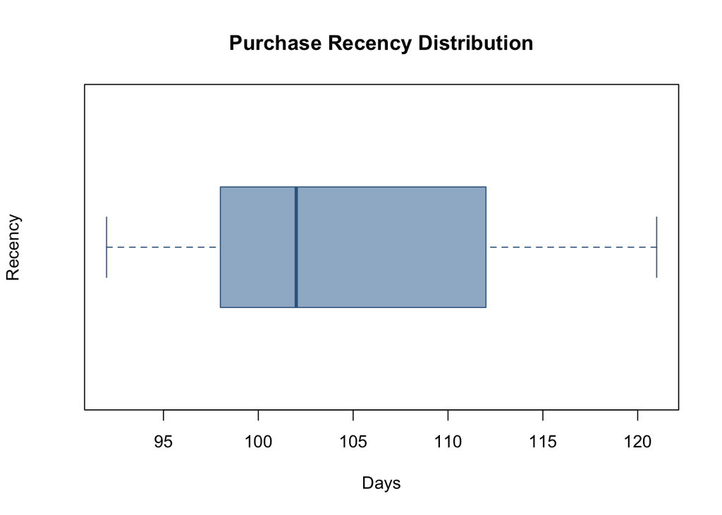

```r
boxplot(purchase_rfm$recency, main = "Purchase Recency Distribution", xlab = "Days", ylab = "Recency", horizontal = TRUE, col = "slategray3", border = "steelblue4")
```

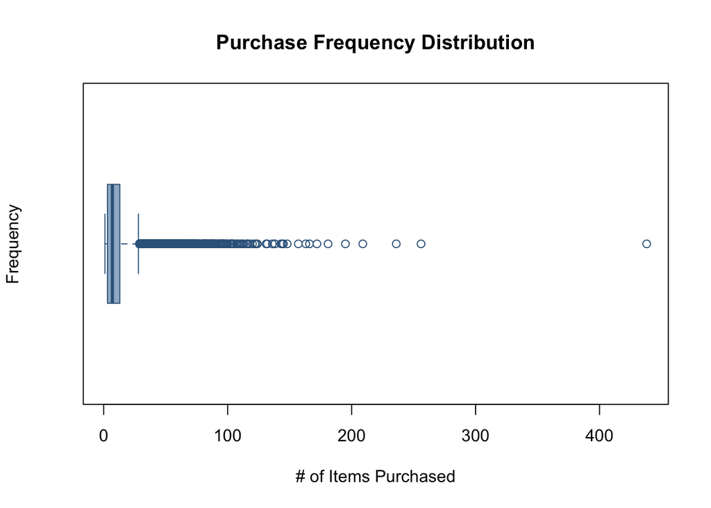

```r
boxplot(purchase_rfm$frequency, main = "Purchase Frequency Distribution", xlab = "# of Items Purchased", ylab = "Frequency", horizontal = TRUE, col = "slategray3", border = "steelblue4")
```

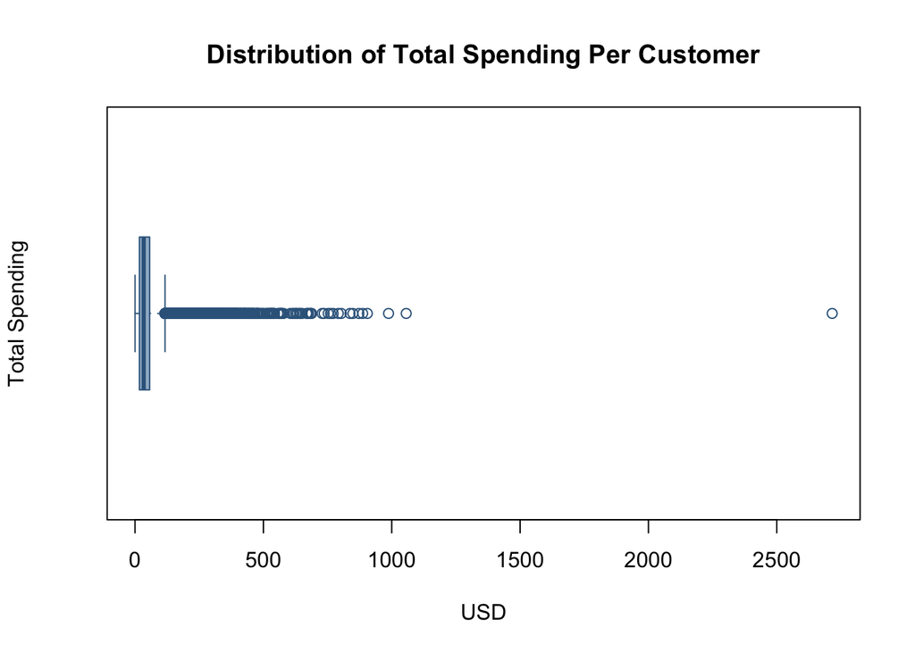

```r
boxplot(purchase_rfm$monetary, main = "Distribution of Total Spending Per Customer", xlab = "USD", ylab = "Total Spending", horizontal = TRUE, col = "slategray3", border = "steelblue4")
```

### Data Standarization

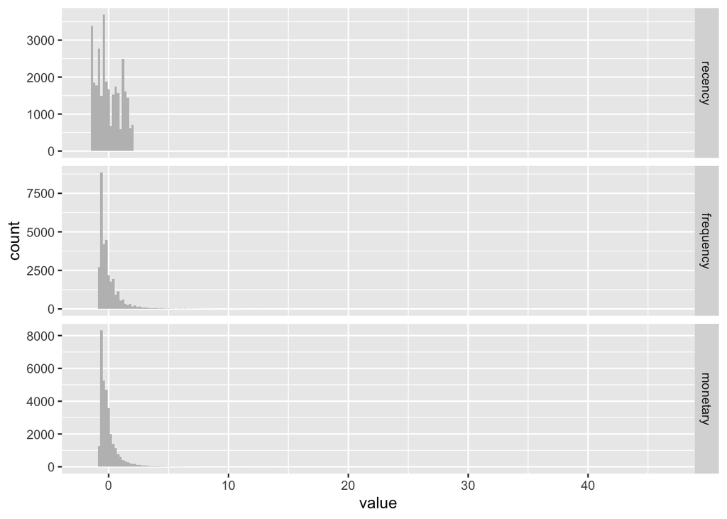

```r
library(ggplot2)
library(reshape2)
scale_rfm <- scale(purchase_rfm[2:4])
ggplot(melt(scale_rfm), aes(x=value)) +
    geom_histogram(fill="gray", binwidth=0.2) +
    facet_grid(Var2~., scales="free")
```

```r
summary(scale_rfm)
```

```
##     recency          frequency          monetary
##  Min.   :-1.4240   Min.   :-0.7587   Min.   :-0.8415
##  1st Qu.:-0.7302   1st Qu.:-0.5943   1st Qu.:-0.5490
##  Median :-0.2676   Median :-0.2654   Median :-0.2566
##  Mean   : 0.0000   Mean   : 0.0000   Mean   : 0.0000
##  3rd Qu.: 0.8888   3rd Qu.: 0.2280   3rd Qu.: 0.1448
##  Max.   : 1.9295   Max.   :35.1745   Max.   :46.3215
```

### Model Fitting

Fit a kmeans clustering on the rfm dataset with k=4.

```r
set.seed(42)
kmeans <- kmeans(purchase_rfm[2:4], centers = 4, nstart = 25)
```

```r
# Identify the optimal k
numCluster <- c(1:10)
sse <- c()
for(n in numCluster){
  sse <- c(sse, mean(kmeans(purchase_rfm[2:4], centers = n)$withinss))
}
```

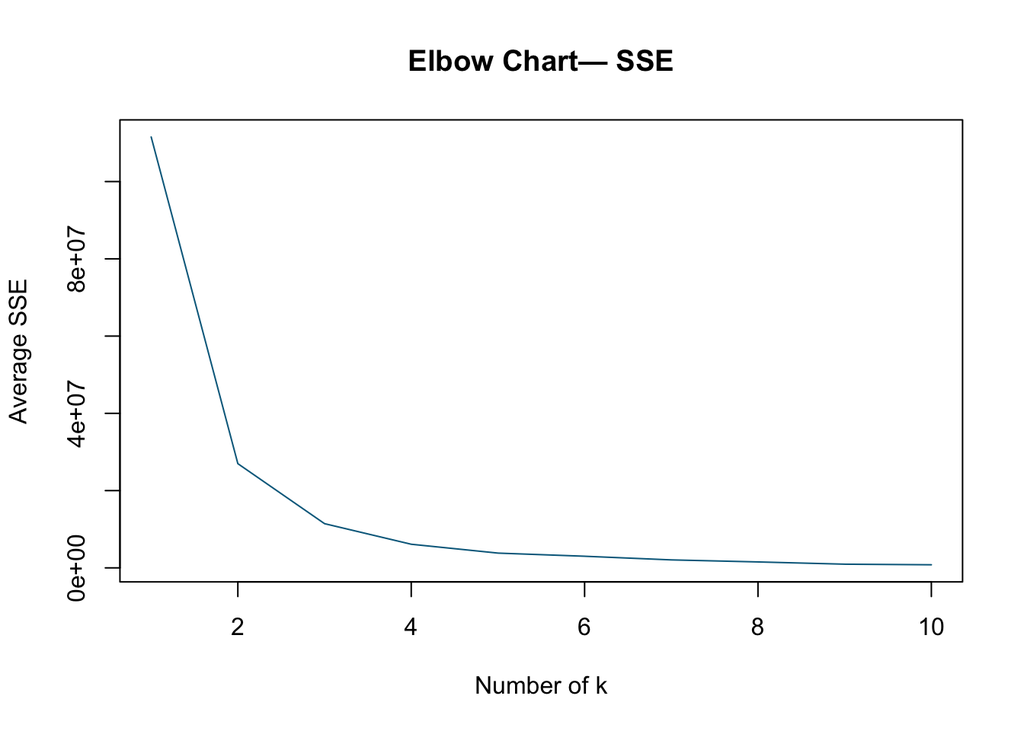

```r
# Plot the elbow graph
plot(numCluster, sse, type = "l",
     main = "Elbow Chart— SSE", xlab = "Number of k", ylab = "Average SSE", col = "deepskyblue4")
```

```r
#install.packages("ggpubr")
#install.packages("factoextra")
library(ggpubr)
library(factoextra)
```

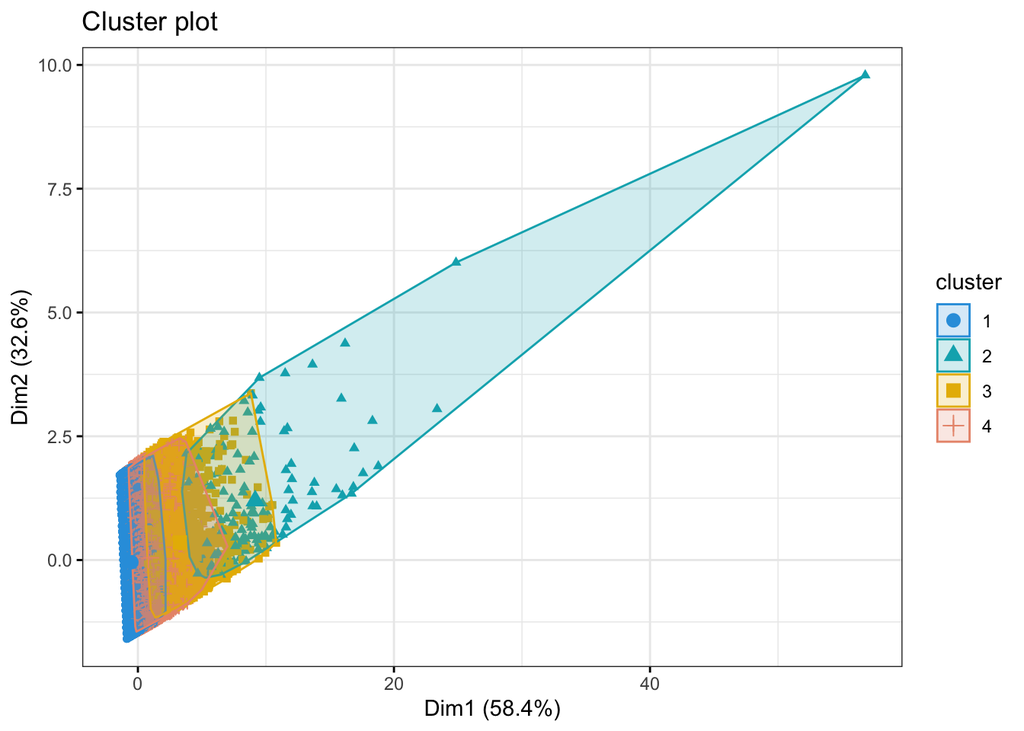

```r
fviz_cluster(kmeans, data = purchase_rfm[2:4],
             palette = c("#2E9FDF", "#00AFBB", "#E7B800", "darksalmon"),
             geom = "point",
             ellipse.type = "convex",
             ggtheme = theme_bw()
             )
```

As we expected, the outliers impacted the model performance significantly.

#### Data Cleaning

Remove outliers from the rfm dataset based on the box plots above.

```r
purchase_rfm <- purchase_rfm[which(purchase_rfm$monetary < 200), ]
purchase_rfm <- purchase_rfm[which(purchase_rfm$frequency < 25), ]
summary(purchase_rfm)
```

```
##      user_id         recency        frequency         monetary
##  9794320 :    1   Min.   : 92.0   Min.   : 1.000   Min.   :  0.13
##  10079204:    1   1st Qu.: 98.0   1st Qu.: 3.000   1st Qu.: 15.87
##  10280338:    1   Median :103.0   Median : 6.000   Median : 29.84
##  15781728:    1   Mean   :104.5   Mean   : 7.477   Mean   : 37.56
##  19762782:    1   3rd Qu.:112.0   3rd Qu.:11.000   3rd Qu.: 48.81
##  28048440:    1   Max.   :121.0   Max.   :24.000   Max.   :199.20
##  (Other) :28677
```

Data distribution after standarization.

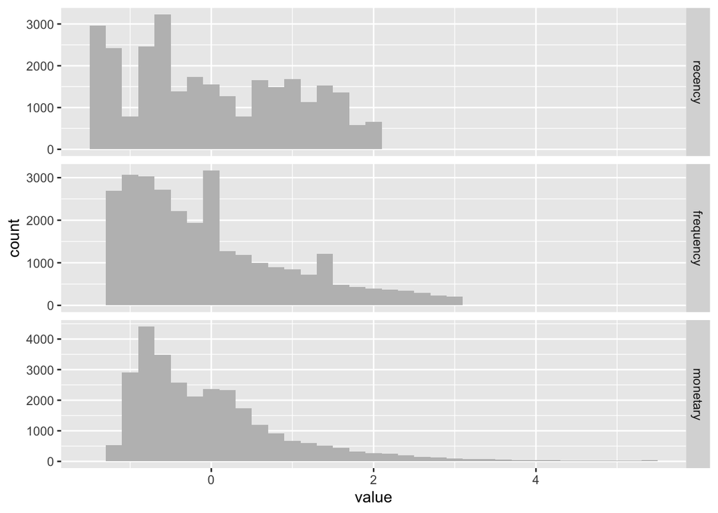

```r
scale_rfm <- scale(purchase_rfm[2:4])
ggplot(melt(scale_rfm), aes(x=value)) +
    geom_histogram(fill="gray", binwidth=0.2) +
    facet_grid(Var2~., scales="free")
```

```r
summary(scale_rfm)
```

```
##     recency          frequency          monetary
##  Min.   :-1.4471   Min.   :-1.1378   Min.   :-1.2696
##  1st Qu.:-0.7540   1st Qu.:-0.7864   1st Qu.:-0.7359
##  Median :-0.1764   Median :-0.2594   Median :-0.2619
##  Mean   : 0.0000   Mean   : 0.0000   Mean   : 0.0000
##  3rd Qu.: 0.8633   3rd Qu.: 0.6190   3rd Qu.: 0.3816
##  Max.   : 1.9030   Max.   : 2.9028   Max.   : 5.4827
```

#### Parameter Tuning

Find the optimal k

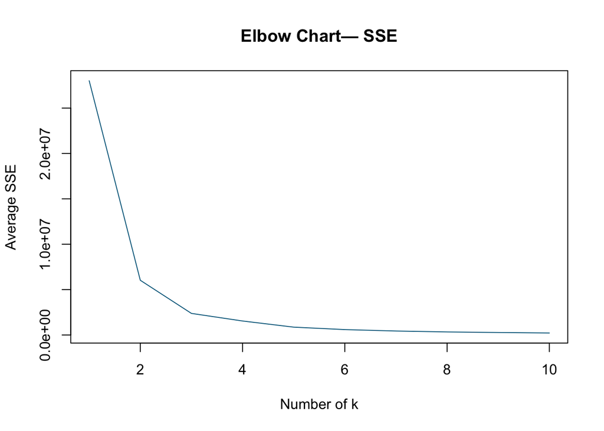

```r
# Identify the optimal k
numCluster <- c(1:10)
sse <- c()
for(n in numCluster){
  sse <- c(sse, mean(kmeans(purchase_rfm[2:4], centers = n)$withinss))
}

# Plot the elbow graph
plot(numCluster, sse, type = "l",
     main = "Elbow Chart— SSE", xlab = "Number of k", ylab = "Average SSE", col = "deepskyblue4")
```

k = 3 seems optimal.

```r
set.seed(42)
kmeans_k4 <- kmeans(scale_rfm, centers = 4, nstart = 25)
kmeans_k3 <- kmeans(scale_rfm, centers = 3, nstart = 25)
```

### Model Performance

For k = 3

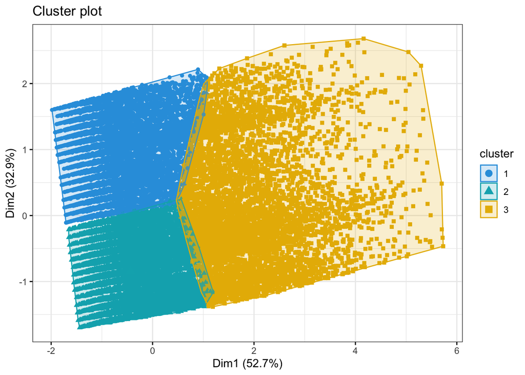

```r
#install.packages("ggpubr")
#install.packages("factoextra")
library(ggpubr)
library(factoextra)
fviz_cluster(kmeans_k3, data = scale_rfm,
             palette = c("#2E9FDF", "#00AFBB", "#E7B800", "darksalmon"),
             geom = "point",
             ellipse.type = "convex",
             ggtheme = theme_bw()
             )
```

For k = 4:

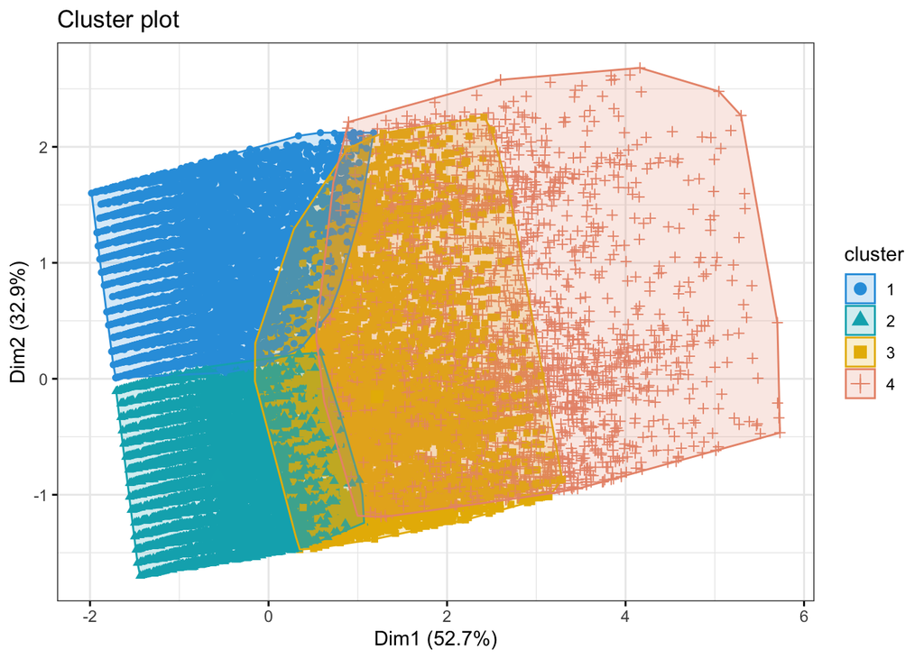

```r
fviz_cluster(kmeans_k4, data = scale_rfm,
             palette = c("#2E9FDF", "#00AFBB", "#E7B800", "darksalmon"),
             geom = "point",
             ellipse.type = "convex",
             ggtheme = theme_bw()
             )
```

### Profiling

```r
# Add segment to the original dataframe
purchase_rfm$segment <- kmeans_k4$cluster
```

```r
recency <- aggregate(recency~segment, purchase_rfm, median)
recency
```

| segment | recency |
| --- | --- |
| 1 | 114 |
| 2 | 98 |
| 3 | 100 |
| 4 | 102 |

| segment <int> | recency <dbl> |  |  |  |
| --- | --- | --- | --- | --- |
| 1 | 114 |  |  |  |
| 2 | 98 |  |  |  |
| 3 | 100 |  |  |  |
| 4 | 102 |  |  |  |

4 rows

```r
frequency <- aggregate(frequency~segment, purchase_rfm, median)
frequency
```

| segment | frequency |
| --- | --- |
| 1 | 4 |
| 2 | 4 |
| 3 | 14 |
| 4 | 15 |

| segment <int> | frequency <dbl> |  |  |  |
| --- | --- | --- | --- | --- |
| 1 | 4 |  |  |  |
| 2 | 4 |  |  |  |
| 3 | 14 |  |  |  |
| 4 | 15 |  |  |  |

4 rows

```r
price <- aggregate(monetary~segment, purchase_rfm, median)
price
```

| segment | monetary |
| --- | --- |
| 1 | 22.21 |
| 2 | 20.29 |
| 3 | 48.83 |
| 4 | 102.15 |

| segment <int> | monetary <dbl> |  |  |  |
| --- | --- | --- | --- | --- |
| 1 | 22.21 |  |  |  |
| 2 | 20.29 |  |  |  |
| 3 | 48.83 |  |  |  |
| 4 | 102.15 |  |  |  |

4 rows

Visualize customer segments on 2D.

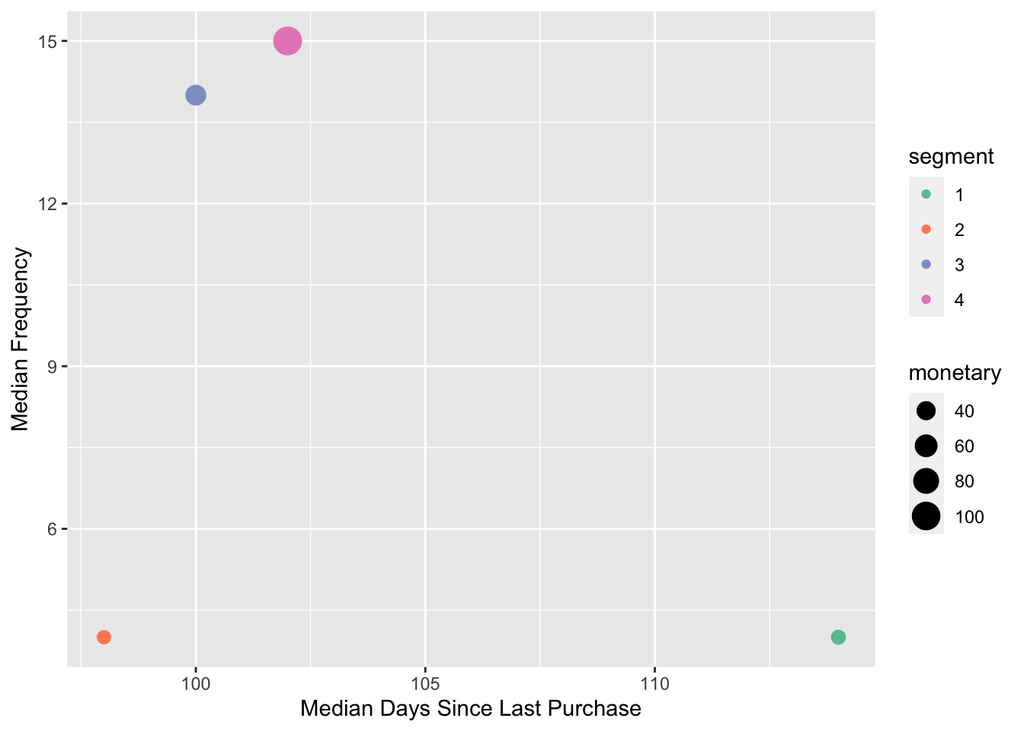

```r
# Merge profile data into one dataframe
seg_result <- merge(recency, frequency, by = "segment", all = TRUE)
seg_result <- merge(seg_result, price, by = "segment", all = TRUE)
seg_result$segment <- as.factor(seg_result$segment)

# Plot the data as a scatterplot
ggplot(seg_result,aes(x=recency,y=frequency, colour=segment, size = monetary))+geom_point()+scale_size_area()+scale_color_brewer(palette = "Set2")+ylab("Median Frequency")+xlab("Median Days Since Last Purchase")
```

## Classification Modeling

We first extract observations for remove_from_cart and purchase to focus on the final stage of customer journey.

```r
# Sort the dataframe so we can follow the customer journey
# cosmetics.df <- cosmetics.df[with(cosmetics.df, order(user_id, product_id, event_time)), ]

# Extract relevant data
purchase_remove.df <- cosmetics.df[which(cosmetics.df$event_type == "purchase" | cosmetics.df$event_type =="remove_from_cart"), ]

# Reset the level for event_type
purchase_remove.df$event_type <- droplevels(purchase_remove.df$event_type)
levels(purchase_remove.df$event_type)
```

```
## [1] "purchase"         "remove_from_cart"
```

```r
summary(purchase_remove.df)
```

```
##    event_time                             event_type       product_id
##  Min.   :2019-11-01 00:00:24   purchase        :322400   5809910:   5099
##  1st Qu.:2019-11-08 20:31:59   remove_from_cart:924778   5809912:   2820
##  Median :2019-11-18 13:38:05                             5854897:   2751
##  Mean   :2019-11-17 06:38:45                             5751422:   2609
##  3rd Qu.:2019-11-24 12:13:56                             5815662:   2596
##  Max.   :2019-11-30 23:59:27                             5700037:   2534
##                                                          (Other):1228769
##               category_id           brand            price
##  1487580007675986944: 90097   runail   : 91934   Min.   :  0.050
##  1487580005595611904: 71778   masura   : 64278   1st Qu.:  1.680
##  1487580005671109376: 55354   irisk    : 61501   Median :  3.090
##  1487580006317032448: 46032   grattol  : 53775   Mean   :  5.008
##  1487580005092295424: 44994   bpw.style: 41247   3rd Qu.:  5.270
##  1602943681873052416: 39511   (Other)  :395482   Max.   :327.780
##  (Other)            :899412   NA's     :538961
##       user_id                                      user_session
##  500179293:   2510   774a7c64-079f-450c-be4a-625aeea3350d:   1744
##  428491295:   2407   d7384499-3793-4f6e-b0cf-0a73016cd217:   1311
##  552908674:   2117   ec103d0c-7d8b-40c1-aadd-de5ac99aadbb:   1147
##  524434718:   1774   daf670cc-a0ab-4cc6-82c9-c581c9a89190:    946
##  548400513:   1683   3e49e56a-9773-4bd8-8e44-b3633350109f:    818
##  486682994:   1500   (Other)                             :1241069
##  (Other)  :1235187   NA's                                :    143
```

### Feature Engineering

```r
# Add a column to track how many days left to Christmas
purchase_remove.df$until_christmas <- as.Date("2019-12-25") - as.Date(purchase_remove.df$event_time)

# Add a column for day of the week
purchase_remove.df$dayOfWeek <- as.factor(weekdays(as.Date(purchase_remove.df$event_time)))

# Add a column for time of the day
purchase_remove.df$timeOfDay <- as.integer(format(purchase_remove.df$event_time, "%H"))
```

### Model Training

Remove the unnecessary columns.

```r
purchase_remove.df <- as.data.frame(subset(purchase_remove.df, select = -c(event_time, user_session, user_id)))
```

Split data into training/testing datasets.

```r
#install.packages('caTools')
library(caTools)
set.seed(42)

# Split data to train/test datasets
sample <- sample.split(purchase_remove.df, SplitRatio = 0.7)
train <- subset(purchase_remove.df, sample == TRUE)
test <- subset(purchase_remove.df, sample == FALSE)
```

Fit a random forest model on the training dataset.

- For mtry = 3:

```r
#install.packages("randomForest")
library(randomForest)
randomforest <- randomForest(event_type ~ price+until_christmas+timeOfDay+dayOfWeek, data = train, mtry = 3)
```

```r
# Running RFMs for varying mtry values
# mtry = c(1:9)
# accuracy = c()
#
# for(num in mtry){
#   set.seed(101)
#   rfm.tmp <- randomForest(event_type ~ price+until_christmas+timeOfDay+dayOfWeek, data = train, mtry = num)
#   pred <- predict(rfm.tmp, test)
#   accuracy <- c(accuracy, accuracy(pred, test$event_type))
#  }
#
# plot(mtry, accuracy, type = "l",
#     main = "Accuracy Rate", xlab = "Number of Variable Sampled at Each Split (mtry)", ylab = "Accuracy Rate", col = "deepskyblue4")
```

### Model Performance

- For mtry = 3:

```r
# Run the random forest on the testing dataset
pred <- predict(randomforest, test)

# Calculate the accuracy rate
library(Metrics)
print(accuracy(pred, test$event_type))
```

```
## [1] 0.7426196
```

```r
# Confusion Matrix
table(pred, test$event_type)
```

```
##
## pred               purchase remove_from_cart
##   purchase            16428            15923
##   remove_from_cart   104452           330890
```